# Lecture 15 - Theory and Homework

This is an [R Markdown](http://rmarkdown.rstudio.com) Notebook

### Lecture 15 - Unsupervised Machine Learning

#### Data import for the exercise:

```r
library(tidyverse)
library(plyr)
# data frame containing information from multiple sensors
DF_Data <- read_csv("DF_Data.csv")
# data frame containing equipment information
DF_Equipm <- read_csv("DF_EquipmData.csv")
# data frame containing Event Names
DF_EvCode <- read_csv("DF_EvCodeData.csv")
# Data manipulation and saving to the DF_TEMP
DF_TEMP <- DF_Data %>%
  # arrange by date
  arrange(StartDateTime) %>%
  # join to decode equipment serial number
  inner_join(DF_Equipm, by = "IDEquipment") %>%
  # select only column needed
  select(StartDateTime, Name, EventCode, TimeTotal) %>%
  # join to decode Event Code meaning
  inner_join(DF_EvCode, by = "EventCode") %>%
  # select only column needed
  select(StartDateTime, Name, TimeTotal, EventText)
```

#### Filter the data…

Can you manually select EventText `"Step 1 SubStep 1"` instead of `"Step 2 SubStep 6"`?

```r
# Data manipulation and saving to the DF_Data reactive value
    DF_KM <- DF_TEMP %>% filter(EventText == "Step 2 SubStep 6")
      # # filters for category
      # filter(EventText == input$Step)
```

Verify your result…

```r
head(DF_KM)
```

| StartDateTime | Name | TimeTotal | EventText |
| --- | --- | --- | --- |
| 2016-10-25 09:09:31 | Machine #1 | 1127 | Step 2 SubStep 6 |
| 2016-11-17 16:05:36 | Machine #1 | 1137 | Step 2 SubStep 6 |
| 2016-11-19 04:30:28 | Machine #1 | 1120 | Step 2 SubStep 6 |
| 2016-11-20 17:10:46 | Machine #1 | 1137 | Step 2 SubStep 6 |
| 2016-11-21 20:09:56 | Machine #4 | 618 | Step 2 SubStep 6 |
| 2016-11-22 04:57:55 | Machine #2 | 947 | Step 2 SubStep 6 |

We will further arrange our data and visualize it before scaling:

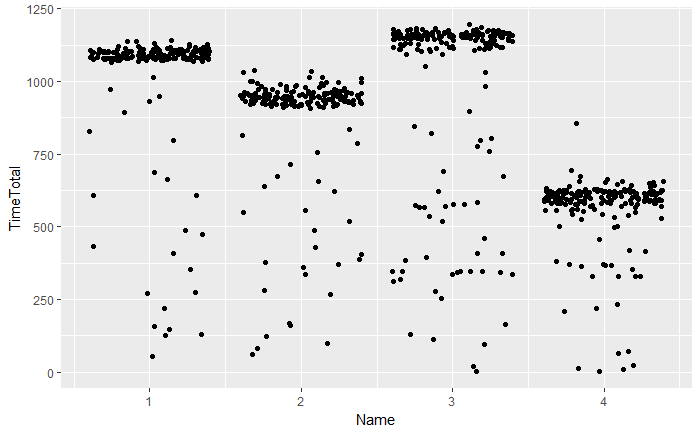

```r
KM <- DF_KM %>%
      select(Name, TimeTotal) %>%
      mutate(Name = revalue(Name, c("Machine #1" = "1", "Machine #2" = "2", "Machine #3" = "3", "Machine #4" = "4"))) %>%
      mutate(Name = as.numeric(Name))
KM  %>%
   ggplot(aes(x = Name, y = TimeTotal)) + geom_jitter()
```

What do you thinking about these points? Do you have any special thoughts? Perhaps do you see something special in the data?

#### Try scaling…

```r
# with scaling
KM_sc <- DF_KM %>%
  select(Name, TimeTotal) %>%
  mutate(Name = revalue(Name, c("Machine #1" = "1", "Machine #2" = "2", "Machine #3" = "3", "Machine #4" = "4"))) %>%
  mutate(Name = as.numeric(Name)) %>%
  scale() %>%
  as.data.frame()
```

#### Try apply scaling in shiny!

This task probably especially intensive. Why don’t we try to add an option directly in `Shiny` that can let the user option to scale the data and directly visualize the result?

**Hint:** Add another `checkBox` in the `ui.R` with `inputId = "scaled"`

**Hint:** You can try simple **if / else** construct :)

#### Try and evaluate differences

Run the app and record steps that significantly alter result of clustering once scaling is performed. Overall what is your mind for the future? Will you use scaling or not… Try to explain your opinion…